# Cardiovascular Diseases Exploratory Data Analysis

## Table of Content

- Data Wrangling
- Univariate Analysis
- Bivariate Analysis
- Multivariate Analysis

### Introduction

Cardiovascular diseases(CVDs) are group of disorders of the heart and blood vessels. They include coronary heart disease, cerebrovascular disease, rheumatic heart disease and other conditions. According to WHO, *CVDs are the leading cause of death globally, taking an estimated 17.9 million lives each year*.

This analysis explores risk factors for cardiovascular diseases. The dataset was gotten from [kaggle](https://www.kaggle.com/datasets/sulianova/cardiovascular-disease-dataset) and consists of 70 000 records of patients data.(*All of the dataset values were collected at the moment of medical examination*.)

**Data Dictionary**

- id - unique identifier for each record
- age - age of patient in days
- height - patient' height in cm
- weight - patient's weight in kg
- gender - patient's sex (1-women, 2-men)
- ap_hi - systolic blood pressure(measures the pressure in your arteries when your heart beats).
- ap_lo - diastolic blood pressure(measures the pressure in your arteries when your heart rests between beats).
- cholesterol - cholesterol level grouped into: (1: normal, 2: above normal, 3: well above normal)
- gluc - glucose level grouped into: (1: normal, 2: above normal, 3: well above normal)
- smoke - whether patient smokes (binary)
- alco - whether patient drinks (binary)
- active - whether patient is active (binary)
- cardio - presence/absence of cvd(binary)

```python
# Importing libaries
import numpy as np
import pandas as pd
import matplotlib.pyplot as plt
import seaborn as sns

import warnings
warnings.filterwarnings('ignore')

%matplotlib inline
```

### Data Wrangling

```python
# read file into pandas dataframe
df = pd.read_csv('cardio_train.csv', sep = ';')
```

```python
# Make copy of data
cardio_df = df.copy()
```

```python
cardio_df.head()
```

|  | id | age | gender | height | weight | ap_hi | ap_lo | cholesterol | gluc | smoke | alco | active | cardio |
| --- | --- | --- | --- | --- | --- | --- | --- | --- | --- | --- | --- | --- | --- |
| 0 | 0 | 18393 | 2 | 168 | 62.0 | 110 | 80 | 1 | 1 | 0 | 0 | 1 | 0 |
| 1 | 1 | 20228 | 1 | 156 | 85.0 | 140 | 90 | 3 | 1 | 0 | 0 | 1 | 1 |
| 2 | 2 | 18857 | 1 | 165 | 64.0 | 130 | 70 | 3 | 1 | 0 | 0 | 0 | 1 |
| 3 | 3 | 17623 | 2 | 169 | 82.0 | 150 | 100 | 1 | 1 | 0 | 0 | 1 | 1 |
| 4 | 4 | 17474 | 1 | 156 | 56.0 | 100 | 60 | 1 | 1 | 0 | 0 | 0 | 0 |

```python
# Rename columns to appropriate names
cardio_df.rename(columns = {'ap_hi':'systolic_bp', 'ap_lo':'diastolic_bp', 'gluc':'glucose', 'alco':'alcohol'},
                 inplace = True)
```

```python
print('Dataset contains {} rows and {} columns'.format(cardio_df.shape[0], cardio_df.shape[1]))
```

```
Dataset contains 70000 rows and 13 columns
```

```python
cardio_df.info()
```

```
<class 'pandas.core.frame.DataFrame'>
RangeIndex: 70000 entries, 0 to 69999
Data columns (total 13 columns):
 #   Column        Non-Null Count  Dtype
---  ------        --------------  -----
 0   id            70000 non-null  int64
 1   age           70000 non-null  int64
 2   gender        70000 non-null  int64
 3   height        70000 non-null  int64
 4   weight        70000 non-null  float64
 5   systolic_bp   70000 non-null  int64
 6   diastolic_bp  70000 non-null  int64
 7   cholesterol   70000 non-null  int64
 8   glucose       70000 non-null  int64
 9   smoke         70000 non-null  int64
 10  alcohol       70000 non-null  int64
 11  active        70000 non-null  int64
 12  cardio        70000 non-null  int64
dtypes: float64(1), int64(12)
memory usage: 6.9 MB
```

```python
# Checking if data is duplicated
sum(cardio_df.duplicated())
```

```
0
```

```python
cardio_df.nunique()
```

```
id              70000
age              8076
gender              2
height            109
weight            287
systolic_bp       153
diastolic_bp      157
cholesterol         3
glucose             3
smoke               2
alcohol             2
active              2
cardio              2
dtype: int64
```

- Data consists of 70000 records and 13 features
- Data is tidy and no missing values
- There are 6 mumerical variables and 7 Categorical Variables(can be seen as 'false numerical' in the data)
- Age is in days instead of years

```python
# Replace 'False numerical' values
cardio_df['cholesterol'].replace({1: 'normal', 2: 'above normal', 3: 'well above normal'}, inplace = True)
cardio_df['glucose'].replace({1: 'normal', 2: 'above normal', 3: 'well above normal'}, inplace = True)
cardio_df['gender'].replace({1: 'female', 2: 'male'}, inplace = True)

columns = ['smoke', 'alcohol', 'active', 'cardio']
for col in columns:
    cardio_df[col].replace({0: 'no', 1: 'yes'}, inplace = True)
```

```python
# Defining function to change age to years
def age_year(column):
    age = np.floor(column/365)    # divide by 365 and round down to next full integer
    age = age.astype('int')       # change to integer datatype
    return age
```

```python
# Applying function to age column
cardio_df['age'] = cardio_df['age'].apply(age_year)
```

```python
# Summary Statistics of data
cardio_df.describe()
```

|  | id | age | height | weight | systolic_bp | diastolic_bp |
| --- | --- | --- | --- | --- | --- | --- |
| count | 70000.000000 | 70000.000000 | 70000.000000 | 70000.000000 | 70000.000000 | 70000.000000 |
| mean | 49972.419900 | 52.840671 | 164.359229 | 74.205690 | 128.817286 | 96.630414 |
| std | 28851.302323 | 6.766774 | 8.210126 | 14.395757 | 154.011419 | 188.472530 |
| min | 0.000000 | 29.000000 | 55.000000 | 10.000000 | -150.000000 | -70.000000 |
| 25% | 25006.750000 | 48.000000 | 159.000000 | 65.000000 | 120.000000 | 80.000000 |
| 50% | 50001.500000 | 53.000000 | 165.000000 | 72.000000 | 120.000000 | 80.000000 |
| 75% | 74889.250000 | 58.000000 | 170.000000 | 82.000000 | 140.000000 | 90.000000 |
| max | 99999.000000 | 64.000000 | 250.000000 | 200.000000 | 16020.000000 | 11000.000000 |

- **Systolic_bp:** contain negative values and incorrect values(we can see values tending to 10,000 above which is impossible, I would investigate this further.
- **Diastolic_bp:** also contains negative values and incorrect values
- **height & weight:** Notice that the minimum weight and height are 10 and 55 which should be an error if the age range of dataset is from 29- 64. Also the maximum values being 200 and 250(which may not be a problem as there are people which theese measurements but rare). These are actually outliers.

```python
# Assessing systolic_bp variable -- treating negative values
cardio_df[cardio_df.systolic_bp <= 0]
```

|  | id | age | gender | height | weight | systolic_bp | diastolic_bp | cholesterol | glucose | smoke | alcohol | active | cardio |
| --- | --- | --- | --- | --- | --- | --- | --- | --- | --- | --- | --- | --- | --- |
| 4607 | 6525 | 41 | female | 165 | 78.0 | -100 | 80 | above normal | normal | no | no | yes | no |
| 16021 | 22881 | 60 | male | 161 | 90.0 | -115 | 70 | normal | normal | no | no | yes | no |
| 20536 | 29313 | 42 | female | 153 | 54.0 | -100 | 70 | normal | normal | no | no | yes | no |
| 23988 | 34295 | 50 | female | 162 | 74.0 | -140 | 90 | normal | normal | no | no | yes | yes |
| 25240 | 36025 | 40 | male | 168 | 50.0 | -120 | 80 | above normal | normal | no | no | no | yes |
| 35040 | 50055 | 63 | male | 168 | 59.0 | -150 | 80 | normal | normal | no | no | yes | yes |
| 46627 | 66571 | 64 | male | 160 | 59.0 | -120 | 80 | normal | normal | no | no | no | no |

The negative values can be seen as input errror as other values seem okay. I would be removing the negative signs.

```python
# Cleaning out negative sign
cardio_df['systolic_bp'] = cardio_df['systolic_bp'].astype('str')
negative = cardio_df[cardio_df['systolic_bp'].str.contains('-')]
negative['systolic_bp'] = negative['systolic_bp'].str.strip('-')
cardio_df['systolic_bp'].update(negative['systolic_bp'])
cardio_df['systolic_bp'] = cardio_df['systolic_bp'].astype('int')
```

```python
# Checking if they were cleaned out
sum(cardio_df.systolic_bp <= 0)
```

```
0
```

```python
# Assessing systolic_bp variable -- treating incorrect values
cardio_df[cardio_df.systolic_bp > 240]
```

|  | id | age | gender | height | weight | systolic_bp | diastolic_bp | cholesterol | glucose | smoke | alcohol | active | cardio |
| --- | --- | --- | --- | --- | --- | --- | --- | --- | --- | --- | --- | --- | --- |
| 1876 | 2654 | 41 | female | 160 | 60.0 | 902 | 60 | normal | normal | no | no | yes | no |
| 2014 | 2845 | 62 | male | 167 | 59.0 | 906 | 0 | normal | normal | no | no | yes | no |
| 4817 | 6822 | 39 | female | 168 | 63.0 | 909 | 60 | above normal | normal | no | no | yes | no |
| 7763 | 11089 | 57 | female | 175 | 80.0 | 11500 | 90 | normal | normal | no | no | yes | yes |
| 8915 | 12710 | 51 | female | 164 | 75.0 | 1420 | 80 | above normal | normal | no | no | yes | yes |
| 9557 | 13616 | 62 | female | 155 | 87.0 | 701 | 110 | normal | normal | no | no | yes | yes |
| 13895 | 19827 | 43 | female | 168 | 72.0 | 1500 | 80 | normal | normal | no | no | yes | yes |
| 17713 | 25314 | 61 | male | 163 | 50.0 | 907 | 70 | well above normal | well above normal | no | no | yes | yes |
| 23867 | 34120 | 44 | female | 161 | 92.0 | 906 | 0 | above normal | normal | no | no | yes | yes |
| 25464 | 36339 | 43 | male | 169 | 75.0 | 14020 | 80 | above normal | normal | no | no | yes | yes |
| 25519 | 36414 | 58 | female | 169 | 71.0 | 14020 | 80 | well above normal | well above normal | no | no | yes | yes |
| 25780 | 36793 | 50 | female | 157 | 83.0 | 1400 | 80 | normal | normal | no | no | yes | yes |
| 28147 | 40239 | 53 | male | 175 | 87.0 | 1620 | 80 | above normal | normal | no | no | yes | yes |
| 29665 | 42410 | 48 | female | 154 | 65.0 | 907 | 70 | normal | normal | no | no | yes | no |
| 31783 | 45400 | 44 | female | 170 | 64.0 | 907 | 0 | normal | normal | no | no | yes | no |
| 36894 | 52725 | 56 | male | 175 | 78.0 | 1130 | 90 | normal | normal | no | no | yes | yes |
| 40330 | 57646 | 55 | female | 162 | 50.0 | 309 | 0 | normal | normal | no | no | yes | no |
| 40831 | 58349 | 54 | female | 162 | 67.0 | 401 | 80 | normal | well above normal | no | no | yes | yes |
| 40852 | 58374 | 47 | female | 169 | 70.0 | 16020 | 80 | normal | normal | no | no | no | yes |
| 41095 | 58728 | 57 | female | 160 | 60.0 | 1202 | 80 | normal | normal | no | no | yes | yes |
| 41505 | 59301 | 57 | female | 154 | 41.0 | 806 | 0 | normal | normal | no | no | yes | no |
| 42397 | 60565 | 49 | male | 176 | 69.0 | 906 | 0 | normal | normal | no | no | yes | no |
| 42658 | 60948 | 56 | male | 182 | 80.0 | 906 | 60 | normal | normal | no | no | yes | yes |
| 43133 | 61618 | 57 | male | 170 | 78.0 | 1400 | 90 | above normal | normal | no | no | yes | no |
| 43208 | 61725 | 64 | female | 165 | 67.0 | 1420 | 80 | above normal | normal | no | no | yes | yes |
| 43504 | 62154 | 53 | female | 158 | 62.0 | 1300 | 80 | well above normal | normal | no | yes | yes | yes |
| 46912 | 66998 | 46 | male | 180 | 78.0 | 14020 | 90 | normal | normal | no | no | yes | yes |
| 47253 | 67502 | 54 | female | 160 | 65.0 | 14020 | 90 | normal | normal | no | no | yes | no |
| 48795 | 69672 | 59 | female | 156 | 76.0 | 1400 | 90 | normal | normal | no | no | yes | yes |
| 50836 | 72539 | 46 | male | 164 | 66.0 | 1409 | 90 | normal | normal | no | no | yes | yes |
| 51438 | 73356 | 51 | male | 168 | 65.0 | 11020 | 80 | normal | normal | no | no | yes | yes |
| 53982 | 77010 | 50 | female | 164 | 54.0 | 960 | 60 | normal | normal | no | no | yes | no |
| 55459 | 79116 | 50 | female | 152 | 76.0 | 13010 | 80 | above normal | above normal | no | no | yes | yes |
| 55847 | 79679 | 63 | female | 161 | 105.0 | 13010 | 80 | normal | normal | no | no | no | no |
| 57291 | 81769 | 60 | male | 166 | 73.0 | 1300 | 90 | normal | normal | no | yes | yes | no |
| 57918 | 82660 | 63 | female | 153 | 63.0 | 1110 | 80 | normal | normal | no | no | no | yes |
| 63996 | 91364 | 46 | female | 168 | 69.0 | 1205 | 90 | normal | normal | no | no | no | yes |
| 64911 | 92655 | 45 | female | 157 | 78.0 | 906 | 60 | above normal | normal | no | no | yes | no |
| 68663 | 98095 | 49 | female | 156 | 41.0 | 906 | 0 | normal | normal | no | no | yes | no |
| 69370 | 99089 | 40 | female | 170 | 74.0 | 2000 | 100 | above normal | normal | no | no | yes | yes |

```python
cardio_df[(cardio_df.systolic_bp > 200) & \
         (cardio_df.systolic_bp < 250) ]
```

|  | id | age | gender | height | weight | systolic_bp | diastolic_bp | cholesterol | glucose | smoke | alcohol | active | cardio |
| --- | --- | --- | --- | --- | --- | --- | --- | --- | --- | --- | --- | --- | --- |
| 1328 | 1863 | 57 | male | 174 | 106.0 | 220 | 120 | well above normal | well above normal | no | no | yes | no |
| 2142 | 3026 | 42 | male | 174 | 113.0 | 210 | 1100 | normal | normal | no | no | yes | yes |
| 2278 | 3208 | 62 | female | 156 | 101.0 | 220 | 110 | normal | above normal | no | no | no | yes |
| 4981 | 7054 | 62 | male | 173 | 74.0 | 220 | 160 | above normal | above normal | no | no | yes | yes |
| 8919 | 12717 | 52 | male | 176 | 61.0 | 210 | 110 | normal | normal | no | no | yes | yes |
| 10386 | 14825 | 58 | female | 167 | 113.0 | 220 | 120 | well above normal | normal | no | no | yes | yes |
| 11269 | 16123 | 51 | female | 161 | 70.0 | 210 | 120 | normal | normal | no | no | yes | yes |
| 11384 | 16282 | 63 | male | 169 | 101.0 | 210 | 100 | above normal | normal | no | no | yes | yes |
| 12129 | 17320 | 56 | female | 166 | 68.0 | 210 | 100 | normal | normal | no | no | yes | no |
| 14805 | 21162 | 54 | female | 157 | 92.0 | 210 | 120 | normal | normal | no | no | yes | yes |
| 15086 | 21577 | 57 | female | 164 | 68.0 | 210 | 110 | normal | normal | no | no | yes | no |
| 15163 | 21681 | 45 | male | 173 | 83.0 | 220 | 100 | above normal | normal | no | no | yes | no |
| 15373 | 21972 | 57 | female | 151 | 80.0 | 202 | 109 | well above normal | above normal | no | no | yes | yes |
| 15789 | 22549 | 54 | female | 159 | 102.0 | 210 | 130 | normal | normal | no | no | yes | no |
| 17946 | 25644 | 57 | male | 162 | 87.0 | 220 | 140 | above normal | above normal | yes | yes | yes | yes |
| 17954 | 25654 | 51 | male | 164 | 100.0 | 210 | 126 | above normal | above normal | no | no | yes | yes |
| 20762 | 29638 | 48 | male | 162 | 82.0 | 210 | 110 | normal | above normal | yes | yes | yes | yes |
| 22471 | 32106 | 63 | male | 180 | 75.0 | 220 | 130 | normal | normal | no | no | yes | yes |
| 23285 | 33266 | 63 | female | 167 | 102.0 | 210 | 100 | above normal | normal | no | no | no | yes |
| 26053 | 37198 | 61 | female | 166 | 102.0 | 240 | 130 | above normal | normal | no | no | yes | yes |
| 26835 | 38359 | 57 | female | 152 | 109.0 | 220 | 120 | above normal | normal | no | no | yes | yes |
| 28136 | 40228 | 57 | female | 160 | 75.0 | 220 | 110 | above normal | normal | no | no | no | yes |
| 29556 | 42252 | 55 | female | 162 | 108.0 | 220 | 110 | well above normal | normal | no | no | no | yes |
| 29652 | 42394 | 54 | male | 174 | 75.0 | 240 | 120 | above normal | normal | no | yes | yes | yes |
| 32560 | 46495 | 58 | male | 176 | 98.0 | 240 | 110 | normal | normal | yes | no | yes | yes |
| 35321 | 50456 | 59 | female | 152 | 87.0 | 220 | 110 | well above normal | well above normal | no | no | no | yes |
| 35369 | 50521 | 57 | male | 165 | 105.0 | 220 | 1100 | well above normal | normal | yes | no | yes | yes |
| 36473 | 52100 | 54 | male | 172 | 89.0 | 210 | 140 | above normal | above normal | no | yes | yes | yes |
| 36640 | 52357 | 64 | male | 165 | 59.0 | 220 | 130 | normal | normal | no | no | yes | yes |
| 42086 | 60106 | 62 | male | 165 | 85.0 | 210 | 1100 | normal | normal | no | no | no | yes |
| 42725 | 61041 | 50 | male | 165 | 76.0 | 240 | 100 | normal | normal | no | no | yes | yes |
| 43575 | 62253 | 64 | female | 155 | 87.0 | 220 | 1120 | well above normal | above normal | no | no | yes | yes |
| 44029 | 62906 | 56 | male | 176 | 68.0 | 210 | 150 | normal | normal | no | no | yes | yes |
| 44767 | 63928 | 45 | female | 160 | 100.0 | 230 | 120 | above normal | normal | no | no | yes | yes |
| 45050 | 64340 | 43 | female | 152 | 85.0 | 207 | 1139 | normal | above normal | no | no | yes | yes |
| 45443 | 64920 | 56 | female | 160 | 82.0 | 210 | 120 | normal | above normal | no | no | yes | yes |
| 46242 | 66045 | 60 | male | 174 | 76.0 | 220 | 120 | above normal | normal | no | no | yes | yes |
| 46350 | 66203 | 55 | male | 175 | 95.0 | 210 | 90 | well above normal | well above normal | no | no | yes | yes |
| 46676 | 66639 | 49 | female | 155 | 83.0 | 220 | 120 | normal | normal | no | no | no | no |
| 47894 | 68391 | 49 | male | 172 | 96.0 | 210 | 120 | normal | normal | no | no | no | yes |
| 48640 | 69459 | 51 | female | 164 | 86.0 | 215 | 110 | well above normal | well above normal | no | no | yes | yes |
| 49103 | 70102 | 59 | female | 161 | 54.0 | 220 | 120 | well above normal | above normal | no | no | yes | yes |
| 50661 | 72298 | 47 | male | 170 | 72.0 | 220 | 100 | normal | normal | no | no | yes | yes |
| 51009 | 72770 | 60 | female | 170 | 152.0 | 220 | 120 | well above normal | normal | no | no | no | no |
| 53889 | 76875 | 55 | male | 170 | 90.0 | 210 | 140 | normal | normal | yes | no | yes | yes |
| 54303 | 77447 | 45 | male | 180 | 115.0 | 210 | 110 | above normal | normal | yes | no | yes | yes |
| 55932 | 79792 | 58 | male | 178 | 90.0 | 210 | 110 | above normal | normal | no | no | yes | no |
| 56014 | 79903 | 60 | male | 176 | 115.0 | 240 | 110 | normal | normal | no | no | yes | no |
| 57968 | 82732 | 53 | female | 170 | 80.0 | 210 | 110 | normal | normal | no | no | no | yes |
| 59251 | 84604 | 52 | male | 176 | 100.0 | 210 | 1140 | normal | normal | no | no | yes | yes |
| 61537 | 87862 | 49 | male | 175 | 68.0 | 220 | 100 | normal | normal | no | no | yes | no |
| 62589 | 89364 | 57 | male | 184 | 99.0 | 220 | 130 | well above normal | well above normal | no | no | yes | yes |
| 64068 | 91461 | 55 | male | 173 | 85.0 | 220 | 1110 | normal | normal | yes | no | yes | yes |
| 64155 | 91574 | 57 | female | 163 | 70.0 | 215 | 106 | above normal | above normal | no | no | yes | yes |
| 64740 | 92409 | 47 | male | 186 | 66.0 | 210 | 110 | normal | normal | yes | no | yes | yes |
| 64778 | 92462 | 53 | male | 172 | 84.0 | 210 | 120 | normal | normal | no | no | yes | yes |
| 66108 | 94377 | 58 | male | 173 | 112.0 | 220 | 1400 | normal | normal | no | no | yes | yes |
| 67710 | 96686 | 53 | male | 168 | 75.0 | 240 | 140 | well above normal | normal | no | no | yes | yes |
| 68579 | 97963 | 54 | male | 171 | 71.0 | 220 | 110 | above normal | normal | no | no | yes | yes |
| 69329 | 99019 | 54 | female | 145 | 62.0 | 240 | 130 | normal | normal | no | no | no | yes |

I noticed that values greater than 240 where ridiculously high and looked more like input errors as compared to those greater than 200 or lessthan/equal to 240. Also, it's impossible to have blood pressures this high with the individual still living. This made me set 240 as my maximum systolic bp.

```python
# Drop rows with systolic_bp > 240(using 240 as maximum)
cardio_df = cardio_df.drop(cardio_df[cardio_df.systolic_bp > 240].index)
sum(cardio_df.systolic_bp > 240)
```

```
0
```

```python
# Assessing diastolic_bp variable -- negative values
cardio_df[cardio_df.diastolic_bp <= 0]
```

|  | id | age | gender | height | weight | systolic_bp | diastolic_bp | cholesterol | glucose | smoke | alcohol | active | cardio |
| --- | --- | --- | --- | --- | --- | --- | --- | --- | --- | --- | --- | --- | --- |
| 13489 | 19258 | 41 | male | 150 | 60.0 | 130 | 0 | normal | normal | no | no | no | no |
| 16459 | 23512 | 56 | female | 156 | 50.0 | 138 | 0 | well above normal | normal | no | no | yes | yes |
| 17381 | 24837 | 49 | female | 164 | 78.0 | 138 | 0 | normal | normal | no | no | yes | no |
| 22923 | 32749 | 58 | male | 166 | 68.0 | 149 | 0 | normal | normal | no | no | yes | yes |
| 25454 | 36325 | 49 | male | 176 | 73.0 | 12 | 0 | normal | normal | no | no | yes | no |
| 27686 | 39577 | 64 | male | 180 | 73.0 | 140 | 0 | normal | normal | yes | yes | yes | yes |
| 38370 | 54780 | 63 | male | 170 | 81.0 | 148 | 0 | normal | normal | no | no | yes | no |
| 43922 | 62754 | 51 | female | 164 | 78.0 | 108 | 0 | above normal | normal | no | no | yes | no |
| 45835 | 65470 | 53 | male | 165 | 70.0 | 140 | 0 | well above normal | normal | yes | no | yes | no |
| 48049 | 68612 | 52 | female | 160 | 84.0 | 121 | 0 | normal | normal | no | no | no | yes |
| 52580 | 75007 | 60 | female | 155 | 66.0 | 13 | 0 | normal | normal | no | no | yes | no |
| 56950 | 81298 | 41 | female | 164 | 70.0 | 120 | 0 | normal | normal | no | no | yes | no |
| 60106 | 85816 | 61 | female | 167 | 74.0 | 15 | -70 | normal | normal | no | no | yes | yes |
| 63787 | 91073 | 40 | male | 161 | 61.0 | 117 | 0 | normal | normal | no | no | yes | no |
| 65303 | 93224 | 64 | male | 176 | 99.0 | 120 | 0 | normal | well above normal | no | no | yes | yes |

While it is possible to have extremely low diastolic pressure, zero value is physically impossible especially when it is compared with the systolic pressure which are a lot higher. Also, it would suggest that that the heart and vessels were basically empty and collapsed. This would be a case of machine error.

```python
# Drop rows with diastolic_bp < 0
cardio_df = cardio_df.drop(cardio_df[cardio_df.diastolic_bp <= 0].index)
sum(cardio_df.diastolic_bp <= 0)
```

```
0
```

```python
# Assessing diastolic_bp variable -- incorrect values
var = cardio_df[cardio_df.diastolic_bp > 140]
var.diastolic_bp.value_counts()
```

```
1000    666
1100    156
1200     21
1110     11
160       9
       ...
1111      1
1002      1
182       1
810       1
602       1
Name: diastolic_bp, Length: 68, dtype: int64
```

```python
# Drop rows with diastolic_bp > 140(using 140 as maximum)
cardio_df = cardio_df.drop(cardio_df[cardio_df.diastolic_bp > 140].index)
sum(cardio_df.diastolic_bp > 140)
```

```
0
```

```python
cardio_df.info()
```

```
<class 'pandas.core.frame.DataFrame'>
Int64Index: 68962 entries, 0 to 69999
Data columns (total 13 columns):
 #   Column        Non-Null Count  Dtype
---  ------        --------------  -----
 0   id            68962 non-null  int64
 1   age           68962 non-null  int32
 2   gender        68962 non-null  object
 3   height        68962 non-null  int64
 4   weight        68962 non-null  float64
 5   systolic_bp   68962 non-null  int32
 6   diastolic_bp  68962 non-null  int64
 7   cholesterol   68962 non-null  object
 8   glucose       68962 non-null  object
 9   smoke         68962 non-null  object
 10  alcohol       68962 non-null  object
 11  active        68962 non-null  object
 12  cardio        68962 non-null  object
dtypes: float64(1), int32(2), int64(3), object(7)
memory usage: 6.8+ MB
```

**What is the structure of your dataset?** There were 70,000 records of patient data (reduced to 68962 after cleaning) and 13 features (id, age, gender, height, weight, systolic_bp, diastolic_bp, cholesterol, glucose, smoke, alcohol, active and cardio). The variables can be grouped as numeric and categorical. The variables cholesterol and glucose are ordered factor variables with the following levels while alcohol, active, active, gender and cardio(target variable) are binary.

(good) ——> (bad)  
cholesterol: normal, above normal, well above normal  
glucose: normal, above normal, well above normal

**What is/are the main feature(s) of interest in your dataset?** I'm interested in figuring out what features are best for predicting the chances of having cvd.

**What features in the dataset do you think will help support your investigation into your feature(s) of interest?** I expect that blood pressure will have the strongest effect on cvd: the higher the blood pressure, the greater risk of cvd. I also think that age, weight, height, cholesterol levels would have contributing effects.

### Univariate Analysis:

This helps to get an overview of each variable in the data.

```python
# order categorical variables
level = ['normal', 'above normal', 'well above normal']
order = pd.api.types.CategoricalDtype(ordered = True, categories = level)
cardio_df['glucose'] = cardio_df['glucose'].astype(order)
cardio_df['cholesterol'] = cardio_df['cholesterol'].astype(order)
cardio_df['cardio'] = cardio_df['cardio'].astype( pd.api.types.CategoricalDtype(ordered = True, categories = ['no', 'yes']))
```

```python
# Setting color palette
red_blue = sns.color_palette('RdYlBu')
blue = red_blue[5]
red = red_blue[0]
light_blue = red_blue[4]
```

```python
# creating a countplot function
def countplot(x, data = cardio_df, figsize = (10,5), xlabel = None, ylabel = None, color=None, palette=None,
              hue=None, title = None, label = True):
    ''' This function returns a countplot
    '''

    # set figure size
    plt.figure(figsize=figsize)

    # Plot graph
    if label == True:
        ax = sns.countplot(x=x, data = data, color = color, palette= palette, hue = hue)
        ax.bar_label(ax.containers[0])
    else:
        ax = sns.countplot(x=x, data = data, color = color, palette= palette, hue = hue)

    # Plot graph labels
    plt.title(title, fontsize=12)
    plt.xlabel(xlabel, fontsize = 11)
    plt.ylabel(ylabel, fontsize =11)
```

I will start by looking at the share of the target variable

**What percentage of the data has cvd?**

```python
yes = str(round((sum(cardio_df.cardio=='yes')/len(cardio_df.cardio)) * 100, 2 )) + '%'
no = str(round((sum(cardio_df.cardio=='no')/len(cardio_df.cardio)) * 100, 2 )) + '%'
```

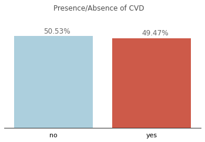

```python
countplot(x='cardio', figsize=(6,3), palette = [light_blue, red], label = False)
plt.gca().spines[['top','left','right']].set_visible(False)
plt.gca().set_yticklabels([])
plt.gca().tick_params(left = False, bottom=False)
plt.gca().text(0, 45000, 'Presence/Absence of CVD', fontsize=12, alpha = 0.7)
plt.gca().text(-0.1, 36000, no, fontsize=12, alpha = 0.6)
plt.gca().text(0.9, 35500, yes, fontsize=12, alpha = 0.6)
plt.xticks(fontsize=11);
```

There is an approximate 50/50 share of patients that have cvd and those that don't.

Next up, the distribution of the sexes in the data

**What is the sex representation of the data?**

```python
male = str(round((sum(cardio_df.gender=='male')/len(cardio_df.gender)) * 100, 2 )) + '%'
female = str(round((sum(cardio_df.gender=='female')/len(cardio_df.gender)) * 100, 2 )) + '%'
```

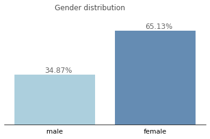

```python
countplot(x='gender',figsize=(6,3), palette = [light_blue, blue], label = False)
plt.gca().spines[['top','left','right']].set_visible(False)
plt.gca().set_yticklabels([])
plt.gca().tick_params(left = False, bottom=False)
plt.gca().text(0, 55000, 'Gender distribution', fontsize=12, alpha = 0.7)
plt.gca().text(-0.1, 25000, male, fontsize=12, alpha = 0.6)
plt.gca().text(0.9, 46000, female, fontsize=12, alpha = 0.6)
plt.xticks(fontsize=11);
```

There is a greater percentage of female to male in this data.Chances are when this variable is used, there may be tendency of bias as the female would seem more affected in most cases.This variable won't be used further.

**What is the age distribution of the data?**

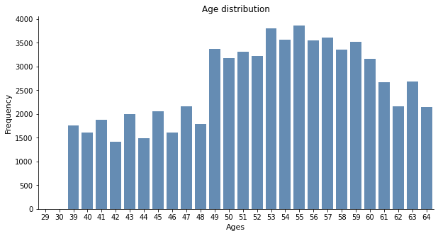

```python
countplot(x='age', xlabel='Ages', ylabel='Frequency',color=blue, title='Age distribution', label = False)
plt.gca().spines[['top', 'right']].set_visible(False)
```

```python
cardio_df[cardio_df.age < 39]
```

|  | id | age | gender | height | weight | systolic_bp | diastolic_bp | cholesterol | glucose | smoke | alcohol | active | cardio |
| --- | --- | --- | --- | --- | --- | --- | --- | --- | --- | --- | --- | --- | --- |
| 6219 | 8850 | 29 | female | 175 | 59.0 | 120 | 80 | normal | normal | no | no | yes | no |
| 22343 | 31922 | 29 | male | 175 | 92.0 | 100 | 60 | normal | normal | no | no | yes | no |
| 30666 | 43842 | 29 | female | 159 | 59.0 | 120 | 80 | normal | normal | no | no | yes | no |
| 55905 | 79749 | 30 | female | 160 | 59.0 | 110 | 70 | normal | normal | no | no | yes | no |

The distribution is bimodal with common frequency at 53 & 55 and with the majority of data are aged 49- 60. There also appear to be less data 39 years of age below. This data captures adults.

Next, let see the distribution of the first predictor variable: blood pressures

**Distribution of systolic and diastolic blood pressure**

```python
# creating a histplot function
def histplot(x, data = cardio_df, figsize=(10,5), xlabel=None, ylabel=None, color=None, palette=None,
             hue=None, bins= 10,title = None):
    ''' This function returns a histplot
    '''

    # set figure size
    plt.figure(figsize=figsize)

    # Plot graph
    sns.histplot(x=x, data = data, color = blue, palette= palette, hue = hue, bins = bins)

    # Plot graph labels
    plt.title(title, fontsize=12)
    plt.xlabel(xlabel, fontsize = 11)
    plt.ylabel('Frequency', fontsize =11)
    plt.gca().spines[['top', 'right']].set_visible(False)
```

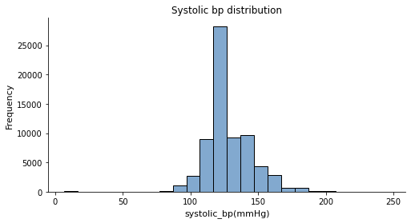

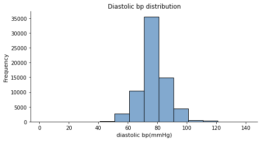

```python
fig, (ax1, ax2) = plt.subplots(2)

bins1 = np.arange(min(cardio_df['systolic_bp']), max(cardio_df['systolic_bp']) + 10, 10)
ax1 = histplot(x='systolic_bp', xlabel= 'systolic_bp(mmHg)', title='Systolic bp distribution', figsize = (8,4), bins = bins1)

bins2 = np.arange(min(cardio_df['diastolic_bp']), max(cardio_df['diastolic_bp'])+ 10, 10)
ax2 = histplot(x='diastolic_bp',xlabel= 'diastolic bp(mmHg)', title='Diastolic bp distribution', figsize = (8,4), bins = bins2)
plt.close(fig);
```

It seems majority of the values are concentrated at the middle with ouliers at both ends. Let check these outliers and see if they need to be filtered

```python
# selecting low systolic bp eyeballed from plots
print(cardio_df.loc[(cardio_df['systolic_bp'] < 50),:].systolic_bp.value_counts())
low_systolic = cardio_df.loc[(cardio_df['systolic_bp'] < 50),:]
low_systolic
```

```
12    75
14    29
11    28
13    13
15    11
10     6
16     3
17     3
20     3
7      1
24     1
Name: systolic_bp, dtype: int64
```

|  | id | age | gender | height | weight | systolic_bp | diastolic_bp | cholesterol | glucose | smoke | alcohol | active | cardio |
| --- | --- | --- | --- | --- | --- | --- | --- | --- | --- | --- | --- | --- | --- |
| 567 | 815 | 58 | female | 168 | 78.0 | 14 | 90 | above normal | normal | no | no | yes | yes |
| 927 | 1294 | 59 | male | 175 | 70.0 | 14 | 90 | well above normal | normal | no | no | yes | yes |
| 979 | 1360 | 49 | female | 172 | 65.0 | 11 | 80 | normal | well above normal | no | no | yes | no |
| 1600 | 2260 | 52 | female | 165 | 66.0 | 12 | 80 | normal | normal | no | no | yes | no |
| 1627 | 2301 | 61 | female | 165 | 71.0 | 14 | 80 | normal | normal | no | no | yes | yes |
| ... | ... | ... | ... | ... | ... | ... | ... | ... | ... | ... | ... | ... | ... |
| 68630 | 98039 | 58 | female | 160 | 59.0 | 12 | 80 | normal | normal | no | no | yes | no |
| 68742 | 98213 | 51 | female | 158 | 74.0 | 14 | 90 | normal | normal | no | no | yes | yes |
| 68998 | 98568 | 52 | female | 154 | 77.0 | 14 | 90 | normal | normal | no | no | yes | no |
| 69137 | 98743 | 42 | male | 176 | 65.0 | 12 | 80 | normal | normal | no | no | yes | no |
| 69549 | 99328 | 58 | female | 155 | 69.0 | 13 | 90 | normal | well above normal | no | no | yes | yes |

173 rows × 13 columns

I found that most of these numbers were below 20 and their diastolic blood pressures were okay. A lot of these values seem like missing zero input error and i will remove them to avoid incorrect results.

```python
# selecting low diastolic bp eyeballed from plots
print(cardio_df.loc[(cardio_df['diastolic_bp'] < 40),:].diastolic_bp.value_counts())
low_diastolic = cardio_df.loc[(cardio_df['diastolic_bp'] < 40),:]
low_diastolic
```

```
20    15
10     7
30     6
8      2
7      2
6      2
1      1
9      1
15     1
Name: diastolic_bp, dtype: int64
```

|  | id | age | gender | height | weight | systolic_bp | diastolic_bp | cholesterol | glucose | smoke | alcohol | active | cardio |
| --- | --- | --- | --- | --- | --- | --- | --- | --- | --- | --- | --- | --- | --- |
| 418 | 594 | 45 | female | 157 | 72.0 | 150 | 30 | normal | normal | no | no | yes | yes |
| 5333 | 7590 | 57 | female | 164 | 102.0 | 120 | 30 | above normal | normal | no | no | yes | no |
| 6737 | 9610 | 45 | female | 156 | 61.0 | 150 | 10 | normal | normal | no | no | no | yes |
| 7598 | 10843 | 40 | male | 70 | 72.0 | 120 | 8 | normal | normal | no | no | yes | no |
| 8797 | 12550 | 57 | female | 162 | 68.0 | 110 | 20 | normal | normal | no | no | yes | no |
| 9777 | 13943 | 59 | female | 166 | 125.0 | 120 | 8 | well above normal | normal | no | no | yes | yes |
| 10106 | 14410 | 50 | female | 152 | 50.0 | 150 | 10 | well above normal | normal | no | no | yes | yes |
| 11820 | 16884 | 49 | female | 169 | 69.0 | 128 | 20 | normal | normal | no | no | yes | yes |
| 13935 | 19885 | 49 | female | 164 | 74.0 | 110 | 20 | normal | normal | no | no | yes | no |
| 18898 | 26983 | 48 | female | 171 | 68.0 | 110 | 7 | normal | normal | no | no | yes | no |
| 18958 | 27069 | 47 | male | 170 | 62.0 | 110 | 20 | normal | normal | no | no | yes | yes |
| 19075 | 27242 | 54 | male | 168 | 68.0 | 110 | 7 | normal | normal | no | no | yes | no |
| 20135 | 28742 | 58 | female | 160 | 72.0 | 110 | 20 | above normal | above normal | no | no | no | no |
| 22380 | 31965 | 44 | male | 170 | 66.0 | 120 | 20 | normal | normal | no | no | yes | yes |
| 23305 | 33295 | 45 | male | 172 | 66.0 | 120 | 20 | normal | normal | no | no | no | no |
| 24757 | 35356 | 55 | female | 168 | 68.0 | 120 | 20 | normal | normal | no | no | yes | yes |
| 26513 | 37874 | 52 | female | 157 | 69.0 | 16 | 10 | well above normal | normal | no | no | yes | yes |
| 28065 | 40122 | 55 | female | 161 | 52.0 | 90 | 6 | normal | normal | no | no | yes | no |
| 33262 | 47533 | 55 | male | 174 | 91.0 | 120 | 30 | normal | normal | no | no | yes | yes |
| 35140 | 50210 | 57 | female | 146 | 55.0 | 130 | 1 | normal | normal | no | no | no | no |
| 36958 | 52813 | 49 | female | 171 | 82.0 | 160 | 30 | normal | normal | no | no | no | yes |
| 37169 | 53102 | 39 | female | 165 | 60.0 | 170 | 10 | normal | normal | no | no | yes | no |
| 38599 | 55119 | 49 | male | 165 | 64.0 | 120 | 9 | normal | normal | no | no | yes | no |
| 39896 | 57023 | 49 | female | 177 | 59.0 | 120 | 20 | above normal | above normal | no | no | yes | yes |
| 40650 | 58088 | 40 | female | 162 | 58.0 | 120 | 20 | normal | normal | no | no | yes | no |
| 40961 | 58537 | 52 | female | 170 | 68.0 | 100 | 20 | normal | normal | no | no | yes | no |
| 43307 | 61874 | 62 | female | 151 | 58.0 | 170 | 10 | well above normal | normal | no | no | yes | yes |
| 44609 | 63710 | 61 | male | 165 | 65.0 | 130 | 20 | normal | normal | no | no | yes | yes |
| 47711 | 68121 | 59 | female | 156 | 100.0 | 140 | 10 | normal | normal | no | no | yes | no |
| 50446 | 71992 | 56 | male | 170 | 77.0 | 120 | 30 | normal | normal | no | no | yes | no |
| 52851 | 75399 | 48 | male | 164 | 64.0 | 24 | 20 | well above normal | normal | no | no | yes | yes |
| 56927 | 81260 | 50 | female | 155 | 76.0 | 70 | 15 | normal | normal | no | yes | yes | yes |
| 57641 | 82269 | 56 | female | 157 | 76.0 | 180 | 20 | normal | normal | no | no | yes | yes |
| 62031 | 88577 | 57 | female | 169 | 75.0 | 120 | 30 | normal | normal | no | no | yes | no |
| 63828 | 91129 | 46 | female | 178 | 69.0 | 110 | 10 | normal | normal | no | no | yes | no |
| 68223 | 97439 | 51 | male | 173 | 100.0 | 130 | 20 | normal | normal | no | no | yes | yes |
| 68568 | 97950 | 42 | female | 163 | 71.0 | 110 | 6 | normal | normal | no | no | yes | no |

```python
# remove incorrect values
cardio_df = cardio_df.drop(low_systolic.index | low_diastolic.index)
```

**Plot blood pressure distribution again**

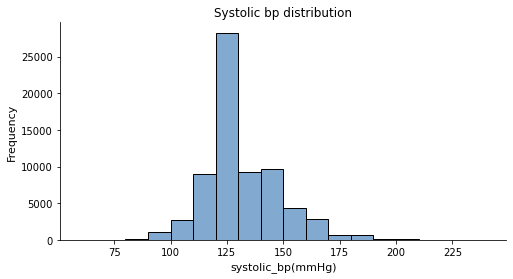

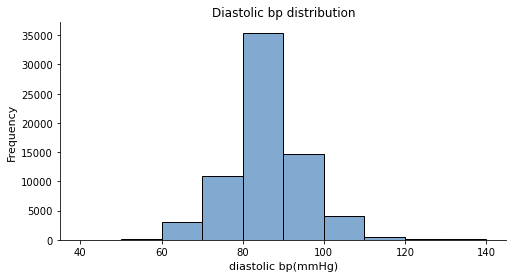

```python
fig, (ax1, ax2) = plt.subplots(2)

bins1 = np.arange(min(cardio_df['systolic_bp']), max(cardio_df['systolic_bp']) + 10, 10)
ax1 = histplot(x='systolic_bp', xlabel= 'systolic_bp(mmHg)', title='Systolic bp distribution', figsize = (8,4), bins = bins1)

bins2 = np.arange(min(cardio_df['diastolic_bp']), max(cardio_df['diastolic_bp'])+ 10, 10)
ax2 = histplot(x='diastolic_bp',xlabel= 'diastolic bp(mmHg)', title='Diastolic bp distribution', figsize = (8,4), bins = bins2)
plt.close(fig);
```

Both distributions are similar, the diastolic distribution looks slightly different(bins are larger which makes sense since it takes a smaller range of values). It's likely that these variables will be correlated with one another. Common values are at intervals 120 and 80(about 75% of the data are above these values) respectively which are the values for the optimal blood pressure. A normal blood pressure are below these values. It would also be good to see the relationship of values above 120 and 80 with cvd since the normal blood pressure should be below this values

Next, let see the distributions of height and weight

**Distribution of Height and Weight**

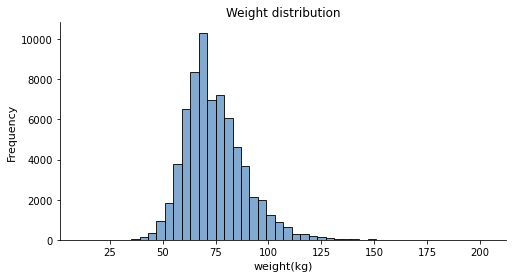

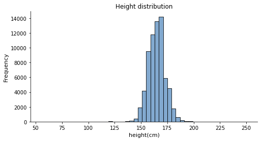

```python
fig, (ax1, ax2) = plt.subplots(2)

bins1 = np.arange(min(cardio_df['weight']), max(cardio_df['weight']) + 4, 4)
ax1 = histplot(x='weight', xlabel= 'weight(kg)', title='Weight distribution', figsize = (8,4), bins = bins1)

bins2 = np.arange(min(cardio_df['height']), max(cardio_df['height'])+ 4, 4)
ax2 = histplot(x='height',xlabel= 'height(cm)', title='Height distribution', figsize = (8,4), bins = bins2)
plt.close(fig);
```

The weight distribution is right skewed with high outliers.The height have some values that will need to be looked into since the range of ages are 29-64.

```python
# selecting low height eyeballed from the plots
low_height = cardio_df.loc[cardio_df['height'] < 100]
low_height
```

|  | id | age | gender | height | weight | systolic_bp | diastolic_bp | cholesterol | glucose | smoke | alcohol | active | cardio |
| --- | --- | --- | --- | --- | --- | --- | --- | --- | --- | --- | --- | --- | --- |
| 224 | 309 | 59 | male | 76 | 55.0 | 120 | 80 | normal | normal | no | no | yes | no |
| 8171 | 11662 | 48 | male | 97 | 170.0 | 160 | 100 | normal | normal | yes | no | yes | yes |
| 12770 | 18218 | 53 | female | 75 | 168.0 | 120 | 80 | normal | normal | yes | no | yes | yes |
| 13265 | 18928 | 61 | male | 71 | 68.0 | 120 | 80 | well above normal | normal | no | no | yes | no |
| 14323 | 20459 | 60 | female | 67 | 57.0 | 120 | 90 | normal | normal | no | no | yes | yes |
| 15167 | 21686 | 43 | female | 70 | 68.0 | 120 | 80 | normal | normal | no | no | no | no |
| 16699 | 23859 | 53 | male | 74 | 98.0 | 140 | 90 | normal | normal | no | no | yes | yes |
| 22542 | 32207 | 39 | female | 68 | 65.0 | 100 | 60 | normal | normal | no | no | no | no |
| 22723 | 32456 | 64 | female | 55 | 81.0 | 130 | 90 | normal | normal | no | no | yes | yes |
| 23913 | 34186 | 52 | female | 81 | 156.0 | 140 | 90 | normal | normal | no | no | yes | no |
| 27384 | 39156 | 41 | female | 80 | 178.0 | 140 | 90 | well above normal | well above normal | no | no | yes | yes |
| 27603 | 39462 | 57 | female | 64 | 61.0 | 130 | 70 | normal | normal | no | no | yes | no |
| 28737 | 41075 | 54 | female | 91 | 55.0 | 140 | 90 | normal | normal | no | no | yes | yes |
| 29157 | 41661 | 52 | female | 60 | 69.0 | 110 | 70 | normal | normal | no | no | no | no |
| 32098 | 45832 | 42 | female | 72 | 74.0 | 150 | 90 | normal | normal | no | no | yes | yes |
| 33607 | 48009 | 53 | male | 65 | 72.0 | 130 | 80 | normal | normal | no | no | no | no |
| 44490 | 63545 | 52 | female | 65 | 60.0 | 120 | 80 | normal | normal | no | no | yes | no |
| 46319 | 66161 | 57 | male | 68 | 71.0 | 120 | 80 | normal | normal | no | no | yes | no |
| 47352 | 67631 | 63 | female | 75 | 75.0 | 120 | 80 | normal | normal | no | no | yes | no |
| 50789 | 72476 | 39 | male | 67 | 60.0 | 110 | 80 | normal | normal | yes | yes | yes | no |
| 51459 | 73386 | 42 | male | 70 | 69.0 | 120 | 80 | normal | normal | no | no | no | no |
| 53344 | 76116 | 56 | male | 67 | 80.0 | 120 | 80 | normal | normal | no | no | no | yes |
| 56022 | 79917 | 58 | female | 96 | 59.0 | 90 | 60 | normal | normal | no | no | yes | yes |
| 64115 | 91523 | 50 | female | 59 | 57.6 | 125 | 67 | normal | normal | no | no | no | no |
| 65302 | 93223 | 50 | female | 99 | 60.0 | 90 | 60 | normal | normal | no | no | yes | no |
| 66643 | 95141 | 51 | female | 57 | 61.0 | 130 | 90 | normal | normal | no | no | yes | yes |

```python
# selecting high height outliers
cardio_df.loc[cardio_df['height'] > 200]
```

|  | id | age | gender | height | weight | systolic_bp | diastolic_bp | cholesterol | glucose | smoke | alcohol | active | cardio |
| --- | --- | --- | --- | --- | --- | --- | --- | --- | --- | --- | --- | --- | --- |
| 6486 | 9223 | 58 | female | 250 | 86.0 | 140 | 100 | well above normal | normal | no | no | yes | yes |
| 21628 | 30894 | 52 | male | 207 | 78.0 | 100 | 70 | normal | normal | no | yes | yes | no |

I used 100cm as the minimum height because if the data captures dwarf, the average height would be around 122cm since the data consists of adults.

```python
# remove incorrect values
cardio_df = cardio_df.drop(low_height.index)
```

```python
# resetting index numbers
cardio_df = cardio_df.reset_index(drop= True)
```

**Plot height and weight distribution again**

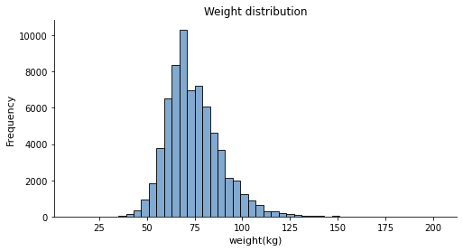

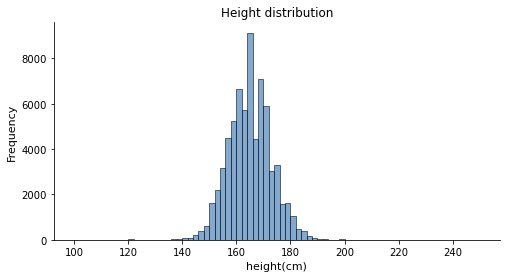

```python
fig, (ax1, ax2) = plt.subplots(2)

bins1 = np.arange(min(cardio_df['weight']), max(cardio_df['weight']) + 4, 4)
ax1 = histplot(x='weight', xlabel= 'weight(kg)', title='Weight distribution', figsize = (8,4), bins = bins1)

bins2 = np.arange(min(cardio_df['height']), max(cardio_df['height'])+ 2, 2)
ax2 = histplot(x='height',xlabel= 'height(cm)', title='Height distribution', figsize = (8,4), bins = bins2)
plt.close(fig);
```

Height variable is unimodal with common height interval 164 and 165 cm which makes sense as the average human height falls within this range. Also, we notice a sharp fall and a spike toward the 170 and 172 mark. Weight is also unimodal and a little right skewed, with its common values between 68-72kg(averagely 70Kg -- which is the standard weight for a physiological man).

Next, let see the other variables

**Distribution of other variables**

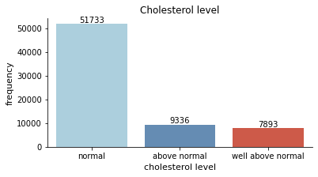

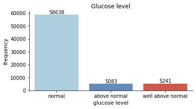

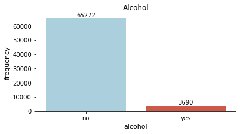

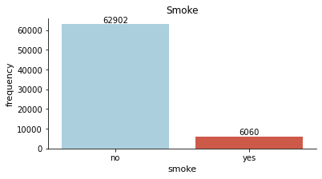

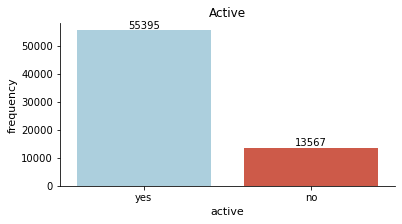

```python
fig, ax = plt.subplots(2)
variables = ['cholesterol', 'glucose']
for var in variables:
    ax = countplot(var, figsize = (6,3), xlabel =  f'{var} level', ylabel = 'frequency',
                palette=[light_blue, blue, red], title = f'{var} level'.capitalize())
    plt.gca().spines[['top', 'right']].set_visible(False)


plt.close(fig)

fig, ax = plt.subplots(3)
variables = ['alcohol', 'smoke', 'active']
for var in variables:
    ax = countplot(var, figsize = (6,3), xlabel =  var, ylabel = 'frequency',
                palette=[light_blue, red], title = var.capitalize())
    plt.gca().spines[['top', 'right']].set_visible(False)

plt.close(fig)
```

In all of the cases, there are more positive instances than negative, that is majority of the data have normal cholesterol and glucose level, not smokers or drinkers and are active.

### Bivariate Analysis

**Does aging increase the chances of having cvd?**

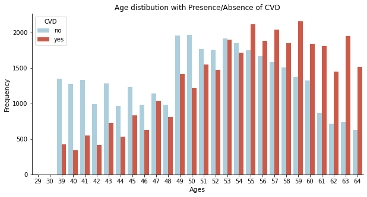

```python
countplot(x='age', xlabel='Ages', ylabel='Frequency',palette=[light_blue, red],hue='cardio',
          title='Age distibution with Presence/Absence of CVD', label = False)
plt.gca().spines[['top', 'right']].set_visible(False)
plt.legend(loc='upper left', title= 'CVD');
```

Notice that lower ages have less cvd occurences as compared to the older groups

Let see the distribution of blood pressure with cvd separately

**Blood Pressures and cvd**

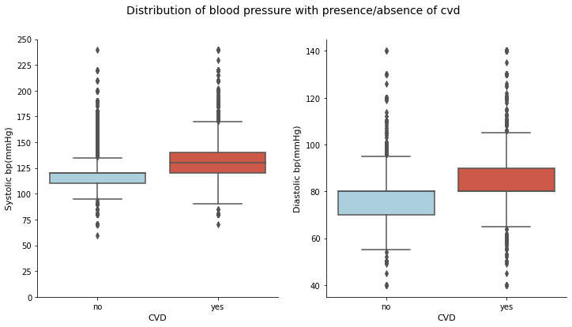

```python
plt.figure(figsize=(12,6))
plt.suptitle('Distribution of blood pressure with presence/absence of cvd', fontsize =14)

plt.subplot(1,2,1)
sns.boxplot(data=cardio_df, y="systolic_bp", x="cardio",  palette = [light_blue, red])
plt.yticks([0, 25, 50, 75, 100, 125, 150, 175, 200, 225, 250])
plt.gca().spines[['top', 'right']].set_visible(False)
plt.xlabel('CVD', fontsize =11)
plt.ylabel('Systolic bp(mmHg)', fontsize = 11)

plt.subplot(1,2,2)
sns.boxplot(data=cardio_df, y="diastolic_bp", x="cardio",  palette = [light_blue,red])
plt.gca().spines[['top', 'right']].set_visible(False)
plt.xlabel('CVD', fontsize =11)
plt.ylabel('Diastolic bp(mmHg)', fontsize = 11);
```

This gives more insight into the distribution of the values by presence/absence of cvd. Remember that 75% of the data are above 120 & 80mmHg, we can see from this chart that a large percent -- about 75%) of that group have cvd.

**Is there a correlation between weight and height?**

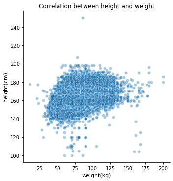

```python
sns.relplot(x='weight',y='height', data= cardio_df, alpha=0.4)
plt.title('Correlation between height and weight', fontsize=12)
plt.xlabel('weight(kg)', fontsize =11)
plt.ylabel('height(cm)', fontsize = 11);
```

These values have a low positive correlation. Most of the values are concentrated at height 140-180, while for the weight they are more distributed. A person weight might increase while still maintaining a particular height.Weight seem more of a varying factor than height, will explore this further with the presence/absence of cardiovascular disease.

**Weight and CVD**

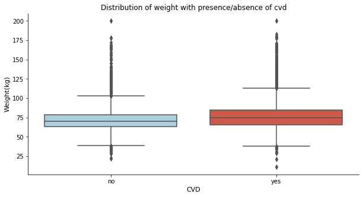

```python
plt.figure(figsize=(10,5))
sns.boxplot(data=cardio_df, y="weight", x="cardio",  palette = [light_blue, red])
plt.title('Distribution of weight with presence/absence of cvd', fontsize=12)
plt.gca().spines[['top', 'right']].set_visible(False)
plt.xlabel('CVD', fontsize =11)
plt.ylabel('Weight(kg)', fontsize = 11);
```

There is no much difference in the weight of those with cvd and those without.

**Featuring a new variable - BMI**  
Body mass index (BMI) is a measure of body fat based on height and weight. It is calculated as $ {bmi} = \frac{weight(kg)}{height(m^2)} $

```python
cardio_df['bmi'] = round(cardio_df.weight/((cardio_df.height/100)** 2), 1)
```

The BMI will be a useful feature to use with cholesterol level.

**Correlation of numeric variables**

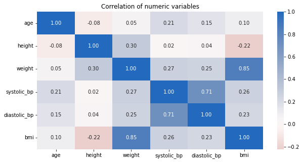

```python
plt.figure(figsize = (10, 5))
numeric_vars = ['age', 'height', 'weight', 'systolic_bp', 'diastolic_bp', 'bmi']
sns.heatmap(cardio_df[numeric_vars].corr(),annot=True,cmap='vlag_r', fmt='.2f', center = 0);
plt.title('Correlation of numeric variables', fontsize = 12);
```

Let see the relationships on a graph using pairgrid

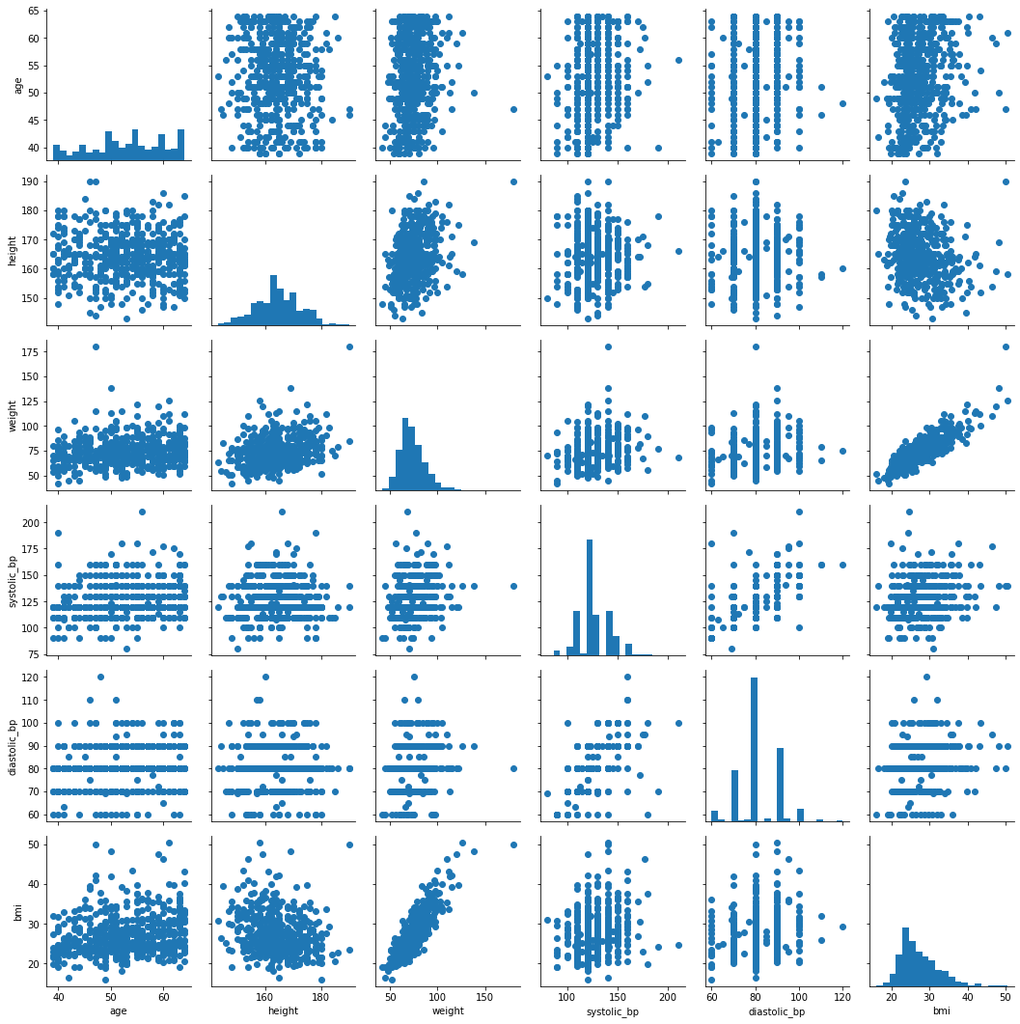

```python
# plot matrix: sample 1000 cardio_df so that plots are clearer and they render faster
samples = np.random.choice(cardio_df.shape[0], 500, replace = False)
cardio_df_samp = cardio_df.loc[samples,:]

g = sns.PairGrid(data = cardio_df_samp, vars = numeric_vars)
g = g.map_diag(plt.hist, bins = 20);
g.map_offdiag(plt.scatter)
```

BMI and weight are highly correlated and this shows that bmi is more dependent on weight than height. Also notice that systolic and diastolic blood pressures are also correlated. Moreover, notice that some data points are low diastolic with high systolic and vice versa. I would want to see the distribution of the blood pressures with cvd.

**PairGrid of numeric features against categorical features**

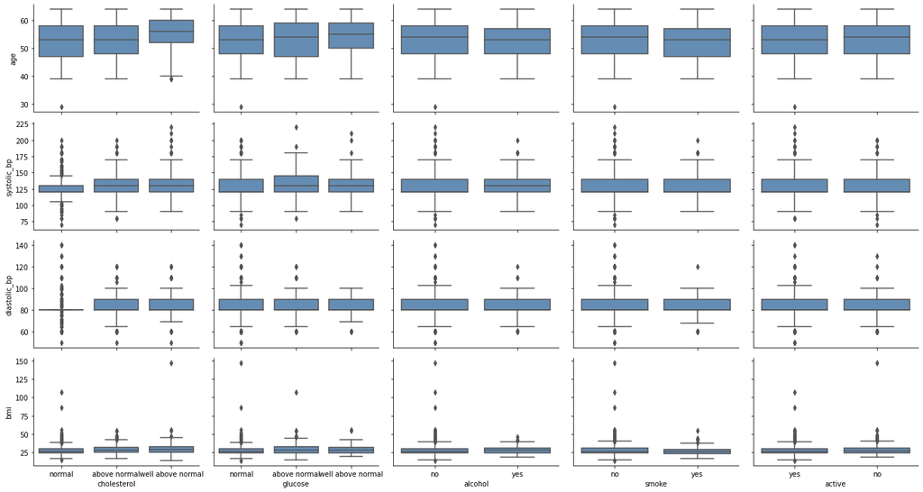

```python
y_vars = ['age','systolic_bp', 'diastolic_bp', 'bmi']
x_vars = ['cholesterol', 'glucose','alcohol', 'smoke', 'active']
# plot matrix of numeric features against categorical features.(sampling to reduce overplotting and run faster)
samples_a = np.random.choice(cardio_df.shape[0], 3000, replace = False)
cardio_df_samp_a = cardio_df.loc[samples_a,:]

plt.figure(figsize = [10, 10])
g = sns.PairGrid(data = cardio_df_samp_a, y_vars = y_vars, x_vars = x_vars, aspect = 1.5)
g.map(sns.boxplot, color = blue)
plt.show();
```

There seem to be an effect of the categorical variables on the distribution of the numeric features(especially on systolic and age). Also, there isn't much difference as to whether a patient is active or not across all numeric variables.

Earlier, we saw the distirbution of blood pressures with cvd(abut 75% of those that have cvd, have elevated-high blood pressures). Lets explore further to see any effect of the categorical on the numeric with the presence or absence of cvd.

### Multivariate Analysis

**Pairgrid of numeric and categorical features with cvd**

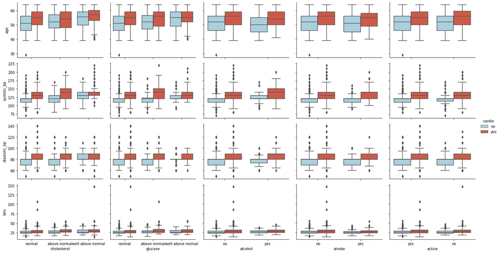

```python
#Using the sampled dataframe above
plt.figure(figsize = [10, 10])
g = sns.PairGrid(data = cardio_df_samp_a, y_vars = y_vars, x_vars = x_vars, aspect = 1.5,
                 hue='cardio', palette=[light_blue, red])
g.map(sns.boxplot)
g.add_legend()
plt.show();
```

From this plot, we can see that even patients with normal glucose or cholesterol level or not smoking etc have cvd.  
Another thing we can note here is, for every pair(cvd or no cvd), the distribution of those that had cvd is higher compared to those that dont have. I also expected bmi to have some relationship with cholesterol level. It is reasonable to say the numeric features here drive the chances of cvd more than the categorical features.

Lastly, let see the correlation of bood pressures with cvd

**Blood pressures and cvd**

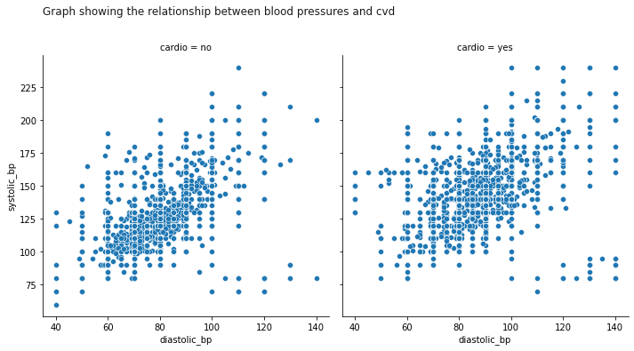

```python
sns.relplot(y='systolic_bp', x='diastolic_bp', data = cardio_df, col='cardio')
plt.gca().text(-80, 280, 'Graph showing the relationship between blood pressures and cvd',
               fontsize=12, alpha = 0.9);
```

**Conclusion:**  
There actually isn't a systematic interaction between the features and cvd(that is you could have a high bp, and an above normal cholesterol level and still not have cvd) although they are major risk factors like high blood pressure, aging which increases the possibility of cvd.